# ggplot2r4ds

answer:we change color on legend and make it “species” and so we get 2 legends(one with color replaced with species as word and one with species actually as we had two aesthetics called color and species in aes() method)

solution:we made another legend of color and called it species and thus if we remove that labs() statement,we can get only one legend as only one categorical variable is mapped to color and shape aesthetics

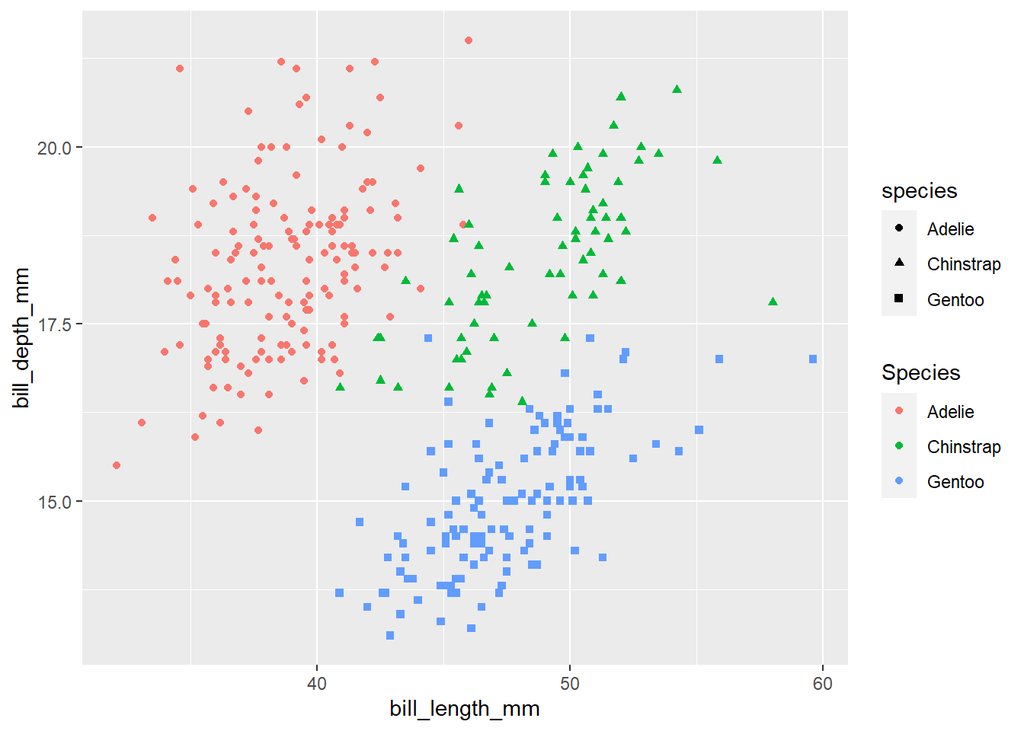

```r
ggplot(
  data = penguins,
  mapping = aes(
    x = bill_length_mm, y = bill_depth_mm,
    color = species, shape = species
  )
) +
  geom_point() +labs(color = "Species")
```

question21

stacked bar plots are on top of each other and using position=fill,we make them frequency plots

result:graph 1:x has island categories and each bar is divided by colors of each species and each bar has same height due to frequency plot and this shows percentage of each category of species on each island(how much proportion of an island does a species occupy) like species a contains 30% of an island B

graph 2:each species on x axis and result is frequency plot of island types on species types(which proportion of a species lives on a particular island–how much proportion of a particular species does an island contain) like 60 percent of a species lives on island B

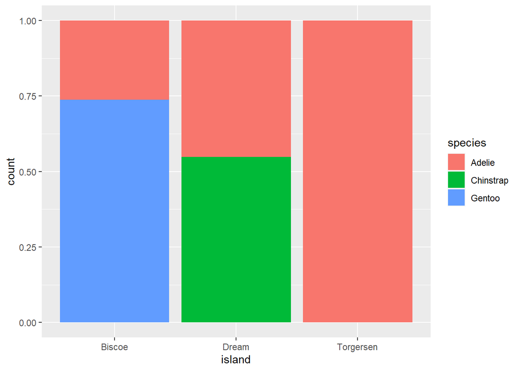

```r
ggplot(penguins, aes(x = island, fill = species)) +
  geom_bar(position = "fill")
```

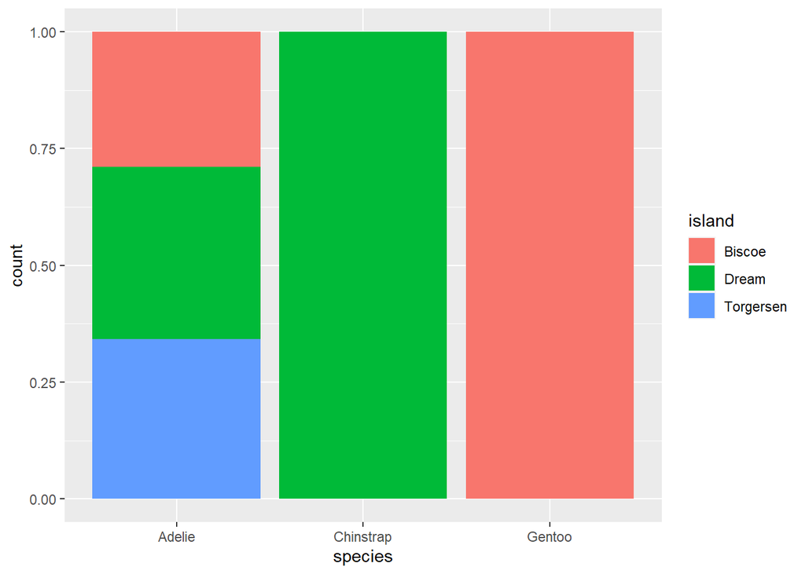

```r
#biscoe contains gentoo and adelie while torgerson contains only adelie
ggplot(penguins, aes(x = species, fill = island)) +
  geom_bar(position = "fill")
```

```r
#adelie is on all 3 islands while rest species are on one stranded island only separately
```

question 22